# 모터-감속기 이상 탐지 — 학습 파이프라인 (Stage 2~4)

> **본격 학습 파이프라인의 학습부 단독 노트북** · Google Colab 용

Stage 1 에서 만든 **4피처 시계열 CSV** 를 입력으로, **(차종 × 센서) 슬롯별 모델**을 학습합니다.

`슬롯 라우팅 → chunker(2000) → 클래스 캡 → MiniRocket 1회 변환 → StratifiedGroupKFold(폴드마다 LR만 재학습) → ModelRegistry`

**사용법** — ① *환경 설정* 셀에서 sktime 설치 + Drive 마운트 → ② *경로 & 파라미터* 셀에서 `CSV_ROOT` / `MODEL_DIR` 두 곳만 채우기 → ③ 위에서 아래로 실행.

산출물: `model_registry.joblib`(슬롯별 모델), `eval_results.json`(평가).

## 0. 환경 설정 (Colab)

```python
# ── 환경 설정  ────────────────────────────────────────────────
# MiniRocket(다변량)은 sktime 에 포함되어 있습니다.
!pip -q install -U sktime
```

## 1. 경로 & 파라미터 설정

```python
# =====================================================================
#  경로 & 파라미터 설정
#  ── Stage 1(PNG→CSV) 결과를 입력으로 사용합니다 ──
# =====================================================================

# [필수] Stage 1 에서 생성한 CSV 들의 루트 (예: "/content/drive/MyDrive/aihub/motor_csv")
CSV_ROOT   = r"C:\Users\jaesung\Desktop\매녀졸프\샘플데이터\03.합성데이터\1.모터_감속기_시계열"     # ← 비워둠. 채우기

# [필수] 학습된 모델 / 평가 결과 저장 경로 (예: "/content/drive/MyDrive/aihub/motor_models")
MODEL_DIR  = r"C:\Users\jaesung\Desktop\매녀졸프\샘플데이터\03.합성데이터\model"      # ← 비워둠. 채우기

# ---------------------------------------------------------------------
#  핵심 파라미터 (기본값 그대로 사용 가능)
# ---------------------------------------------------------------------
CHUNK_SIZE   = 2000          # 청크 1개 = 2000 행 (≈ 원본 PNG 1장 분량). 고정 길이 시계열 샘플
FEATURE_COLS = ["peak_freq_bin", "band_start", "band_end", "rms"]  # 4채널 (multivariate)
CLASS_ORDER  = ["DEMAG", "ECC10", "ECC20", "NORMAL", "REDUC"]   # 5클래스 고정 순서
N_SPLITS     = 3             # StratifiedGroupKFold 분할 수 (≥3 권장)
NUM_KERNELS  = 10000         # MiniRocket 커널 수 (≈ 피처 차원). 느리면 5000 으로 낮추기
RANDOM_STATE = 42

# ---------------------------------------------------------------------
#  속도 · 메모리 (대용량 학습용)
#   원본 PNG 가 클래스별로 균형이므로 별도 불균형 보정은 거의 불필요.
#   대신 "중복 청크"가 너무 많아 느려지는 것을 캡으로 막습니다.
#   (같은 세션에서 잘린 청크들은 신호가 거의 동일 → 전부 학습할 필요 없음)
# ---------------------------------------------------------------------
CHUNK_CAP_PER_CLASS = 4000   # 슬롯·클래스당 최대 청크 수 (None = 제한 없음)
MINIROCKET_N_JOBS   = -1     # MiniRocket 변환 병렬 코어 수 (-1 = 전체 코어)
LR_MAX_ITER         = 1000    # LogisticRegression 최대 반복수 (표준화 피처면 보통 충분)

# ---------------------------------------------------------------------
#  불균형 처리 (PNG 균형이라 기본 OFF, 필요 시 보험용)
# ---------------------------------------------------------------------
LR_CLASS_WEIGHT = None       # "balanced" 로 두면 클래스 가중치 적용 (데이터는 그대로 둠)
```

## 2. 데이터 유틸 — 스캔 · 슬롯 분류 · 청킹

CSV 를 `(vehicle, sensor)` 슬롯으로 묶고, 각 CSV(연속 세션)를 `CHUNK_SIZE`(2000) 행씩 잘라 고정 길이 다변량 샘플(**청크**)로 만듭니다. 청크 1개는 원본 PNG 약 1장 분량이며, 각 청크는 원본 CSV 의 `group_key` 를 상속해 **데이터 누수 방지**에 사용됩니다. (슬롯·클래스당 청크 수 제한은 다음 단계의 `CHUNK_CAP_PER_CLASS` 에서 적용됩니다.)

```python
# =====================================================================
#  데이터 유틸 — CSV 스캔 · 슬롯 분류 · 청킹
#   슬롯 = (vehicle, sensor)  →  최대 3차종 × 3센서 = 9개
#   청크 = 한 CSV(연속 세션)를 CHUNK_SIZE 행씩 자른 고정 길이 샘플
# =====================================================================
import os, glob
import numpy as np
import pandas as pd
from collections import defaultdict
from pathlib import Path


def find_csv_paths(root):
    return sorted(glob.glob(os.path.join(root, "**", "*.csv"), recursive=True))


def slot_of_csv(path):
    """CSV 첫 행에서 (vehicle, sensor, fault_class) 읽기 (가벼움)."""
    head = pd.read_csv(path, nrows=1, usecols=["vehicle", "sensor", "fault_class"])
    return (str(head["vehicle"].iloc[0]),
            str(head["sensor"].iloc[0]),
            str(head["fault_class"].iloc[0]))


def scan_slots(root):
    """모든 CSV 를 (vehicle, sensor) 슬롯으로 묶고, 슬롯별 등장 클래스 집합을 기록."""
    slots, slot_classes = defaultdict(list), defaultdict(set)
    for p in find_csv_paths(root):
        try:
            v, s, fc = slot_of_csv(p)
        except Exception as e:
            print("스킵(헤더 읽기 실패):", p, "→", e)
            continue
        slots[(v, s)].append(p)
        slot_classes[(v, s)].add(fc)
    return slots, slot_classes


def load_slot_chunks(paths):
    """
    슬롯에 속한 CSV 들을 읽어 청크 단위 샘플로 변환.
    반환: X (n_chunks, C, CHUNK_SIZE), y (n_chunks,), groups (n_chunks,) | None
    각 청크의 label = 해당 CSV 의 fault_class, group = group_key (누수 방지용).
    """
    Xs, ys, gs = [], [], []
    for p in paths:
        try:
            df = pd.read_csv(p)
        except Exception as e:
            print("스킵(읽기 실패):", p, "→", e); continue
        if df.empty:
            continue
        feats = df[FEATURE_COLS].to_numpy(dtype=np.float32)     # (n, C)
        n = (len(feats) // CHUNK_SIZE) * CHUNK_SIZE             # 끝의 잔여행(<2000) 버림
        if n == 0:
            continue
        C = feats.shape[1]
        chunks = feats[:n].T.reshape(C, -1, CHUNK_SIZE).transpose(1, 0, 2)  # (n_chunks, C, L)
        label = str(df["fault_class"].iloc[0])
        group = str(df["group_key"].iloc[0])
        Xs.append(chunks)
        ys += [label] * len(chunks)
        gs += [group] * len(chunks)
    if not Xs:
        return None
    return np.concatenate(Xs, 0), np.array(ys), np.array(gs)
```

## 3. 슬롯 스캔 — 학습 가능 여부 확인

```python
# # =====================================================================
# #  슬롯 스캔 실행 — 어떤 슬롯이 학습 가능한지 먼저 확인
# # =====================================================================
# if not CSV_ROOT:
#     raise ValueError("CSV_ROOT(Stage 1 출력 CSV 경로)를 먼저 채워주세요.")

slots, slot_classes = scan_slots(CSV_ROOT)
# print(f"발견된 슬롯(차종 × 센서): {len(slots)}개\n")
# for k in sorted(slots, key=lambda x: (str(x[0]), str(x[1]))):
#     cls = sorted(slot_classes[k])
#     flag = "" if len(cls) >= 2 else "   ⚠ 단일 클래스 → 분류 학습 불가(스킵 예정)"
#     print(f"  {str(k[0]):6s} · {str(k[1]):10s} | CSV {len(slots[k]):4d}개 | 클래스 {cls}{flag}")
```

## 4. 모델 정의 — MiniRocket(다변량) + LogisticRegression

채널별 표준화 → **MiniRocket 특징 변환(슬롯당 1회)** → StandardScaler → LogisticRegression.

무거운 MiniRocket 변환은 슬롯마다 **한 번만** 수행하고, 교차검증 폴드에서는 가벼운 **LogisticRegression 만 다시 학습**해 속도를 크게 높였습니다. 학습 전 `CHUNK_CAP_PER_CLASS` 로 슬롯·클래스당 청크 수를 제한해 중복을 줄입니다. 예측은 항상 5클래스(CLASS_ORDER) 정렬 확률을 반환하며(없는 클래스는 0), `StratifiedGroupKFold` 로 group 누수 방지 + 클래스 비율 유지를 동시에 달성하고, 마지막에 전체 데이터로 LR 을 재학습한 모델을 저장합니다.

```python
# =====================================================================
#  모델 정의 — MiniRocket(다변량) + LogisticRegression
#   핵심 최적화:
#    (1) 슬롯·클래스당 청크 수를 CHUNK_CAP_PER_CLASS 로 제한 (중복 제거 → 속도/메모리↓)
#    (2) MiniRocket 변환을 "슬롯당 1번"만 하고 폴드마다 재사용 (변환 약 4배 절감)
#    (3) LR 반복수 축소. 5클래스 정렬 확률 반환은 그대로 유지
# =====================================================================
from sklearn.preprocessing import StandardScaler
from sklearn.linear_model import LogisticRegression


def make_minirocket(n_channels):
    if n_channels == 1:
        from sktime.transformations.panel.rocket import MiniRocket
        return MiniRocket(num_kernels=NUM_KERNELS, random_state=RANDOM_STATE,
                          n_jobs=MINIROCKET_N_JOBS)
    from sktime.transformations.panel.rocket import MiniRocketMultivariate
    return MiniRocketMultivariate(num_kernels=NUM_KERNELS, random_state=RANDOM_STATE,
                                  n_jobs=MINIROCKET_N_JOBS)


def _fit_channel_stats(X):
    mean = X.mean(axis=(0, 2)).astype(np.float32)
    std  = X.std(axis=(0, 2)).astype(np.float32)
    std[std == 0] = 1.0
    return mean, std


def _apply_channel(X, mean, std):
    return ((X - mean[None, :, None]) / std[None, :, None]).astype(np.float32)


def cap_per_class(X, y, g, cap, seed=RANDOM_STATE):
    """슬롯·클래스당 청크 수를 cap 개로 제한(무작위 추출). cap 이 None 이면 그대로 둠.
    같은 세션 청크는 신호가 거의 같아 전부 쓸 필요가 없으므로 속도/메모리를 크게 줄인다."""
    if not cap:
        return X, y, g
    rng = np.random.default_rng(seed)
    keep = []
    for c in np.unique(y):
        idx = np.where(y == c)[0]
        keep.append(rng.choice(idx, min(cap, len(idx)), replace=False))
    keep = np.sort(np.concatenate(keep))
    return X[keep], y[keep], g[keep]


def build_features(X):
    """채널 표준화 + MiniRocket 적합/변환을 '한 번'만 수행.
    반환한 F(특징 행렬)를 교차검증 폴드와 최종 학습에서 공유해 변환 비용을 줄인다."""
    mean, std = _fit_channel_stats(X)
    Xn = _apply_channel(X, mean, std)
    mr = make_minirocket(Xn.shape[1])
    mr.fit(Xn)
    F = np.asarray(mr.transform(Xn), dtype=np.float32)   # (n_chunks, ~NUM_KERNELS)
    return mean, std, mr, F


def fit_lr(Ftr, ytr):
    """MiniRocket 특징(F) 위에서 StandardScaler + LogisticRegression 만 적합."""
    sc = StandardScaler().fit(Ftr)
    lr = LogisticRegression(max_iter=LR_MAX_ITER, class_weight=LR_CLASS_WEIGHT,
                        solver="saga", n_jobs=-1)
    lr.fit(sc.transform(Ftr), ytr)
    return sc, lr


def _proba_aligned(sc, lr, F):
    """(n, 5) — CLASS_ORDER 순서로 정렬된 확률(없는 클래스는 0). 이미 변환된 F 를 입력."""
    p = lr.predict_proba(sc.transform(F))
    full = np.zeros((len(F), len(CLASS_ORDER)), dtype=float)
    for j, c in enumerate(lr.classes_):
        full[:, CLASS_ORDER.index(str(c))] = p[:, j]
    return full


def slot_proba(model, X):
    """배포용: 원본 청크 X 를 받아 전체 파이프라인으로 5클래스 확률 반환."""
    Xn = _apply_channel(X, model["ch_mean"], model["ch_std"])
    F = np.asarray(model["mr"].transform(Xn), dtype=np.float32)
    return _proba_aligned(model["sc"], model["lr"], F)


def slot_predict(model, X):
    return np.array(CLASS_ORDER)[slot_proba(model, X).argmax(1)]


def train_slot(slot_key, X, y, g):
    """슬롯 1개 학습: 청크 캡 → MiniRocket 1회 변환 → StratifiedGroupKFold CV → 전체 재학습."""
    from sklearn.model_selection import StratifiedGroupKFold
    from sklearn.metrics import f1_score, accuracy_score, confusion_matrix

    info = dict(slot=slot_key, n_chunks=int(len(y)), classes=sorted(set(map(str, y))))
    if len(set(y)) < 2:
        info["status"] = "skipped: 단일 클래스 (분류 불가)"
        return None, info

    # (1) 슬롯·클래스당 청크 캡 (중복 제거)
    X, y, g = cap_per_class(X, y, g, CHUNK_CAP_PER_CLASS)
    info["n_chunks"] = int(len(y))
    info["classes"]  = sorted(set(map(str, y)))
    labels = sorted(set(map(str, y)))

    # (2) MiniRocket 변환은 슬롯당 1번만 → 폴드/최종학습에서 재사용
    #     주의: MiniRocket·채널표준화를 전체 데이터로 적합하므로 약한 정보 누수가 있으나,
    #     MiniRocket 은 비지도 변환이라 관례상 허용 수준(변환 비용 약 4배 절감 트레이드오프).
    mean, std, mr, F = build_features(X)

    # 클래스별 그룹 수로 가능한 분할 수 결정 (StratifiedGroupKFold 제약)
    min_groups = min(len(set(g[y == c])) for c in labels)
    n_splits = min(N_SPLITS, min_groups)

    if n_splits >= 2:
        sgkf = StratifiedGroupKFold(n_splits=n_splits, shuffle=True, random_state=RANDOM_STATE)
        f1s, accs, cm_total = [], [], None
        for tr, va in sgkf.split(np.zeros(len(y)), y, g):
            sc, lr = fit_lr(F[tr], y[tr])                       # ← 폴드마다 LR 만 재학습
            pred = np.array(CLASS_ORDER)[_proba_aligned(sc, lr, F[va]).argmax(1)]
            f1s.append(f1_score(y[va], pred, average="macro", labels=labels, zero_division=0))
            accs.append(accuracy_score(y[va], pred))
            cm = confusion_matrix(y[va], pred, labels=labels)
            cm_total = cm if cm_total is None else cm_total + cm
        info.update(status="ok", n_splits=int(n_splits), labels=labels,
                    macro_f1_mean=float(np.mean(f1s)), macro_f1_std=float(np.std(f1s)),
                    acc_mean=float(np.mean(accs)), acc_std=float(np.std(accs)),
                    confusion_matrix=cm_total.tolist())
    else:
        info.update(status=f"trained (CV 생략: 클래스당 그룹 수 부족 min_groups={min_groups})",
                    labels=labels)

    # (3) 최종 배포 모델: 동일 MiniRocket(mr) 재사용 + 전체 F 로 LR 재학습
    sc, lr = fit_lr(F, y)
    final_model = dict(ch_mean=mean, ch_std=std, mr=mr, sc=sc, lr=lr,
                       classes=list(map(str, lr.classes_)))
    return final_model, info
```

## 5. 전체 학습 실행 → ModelRegistry 저장

모든 슬롯을 학습해 `{(vehicle, sensor): model}` 형태의 ModelRegistry 로 저장합니다. 학습 불가 슬롯은 사유와 함께 평가 결과에 기록됩니다.

```python
%%time
# =====================================================================
#  전체 학습 실행 → ModelRegistry + 평가 결과 저장
#   슬롯마다 중간 저장(체크포인트)하여 크래시/세션 종료에 대비합니다.
# =====================================================================

import json, joblib
from tqdm.auto import tqdm

if not MODEL_DIR:
    raise ValueError("MODEL_DIR(저장 경로)를 먼저 채워주세요.")
os.makedirs(MODEL_DIR, exist_ok=True)

reg_path  = os.path.join(MODEL_DIR, "model_registry.joblib")
eval_path = os.path.join(MODEL_DIR, "eval_results.json")

registry, eval_rows = {}, []
for slot_key in tqdm(sorted(slots, key=lambda x: (str(x[0]), str(x[1]))), desc="슬롯 학습"):
    data = load_slot_chunks(slots[slot_key])
    if data is None:
        eval_rows.append(dict(slot=slot_key, n_chunks=0, status="skipped: 청크 없음"))
        continue
    X, y, g = data
    model, info = train_slot(slot_key, X, y, g)
    eval_rows.append(info)
    if model is not None:
        registry[slot_key] = model
        joblib.dump(registry, reg_path)                 # ← 슬롯마다 중간 저장
        with open(eval_path, "w", encoding="utf-8") as f:
            json.dump(eval_rows, f, ensure_ascii=False, indent=2, default=str)

# 최종 저장 (루프에서 이미 저장되지만 안전하게 한 번 더)
joblib.dump(registry, reg_path)
with open(eval_path, "w", encoding="utf-8") as f:
    json.dump(eval_rows, f, ensure_ascii=False, indent=2, default=str)

print(f"\n학습 완료 — 등록된 모델 {len(registry)}개")
print("저장:", reg_path)
```

[output not shown]

[output cut: 15 more lines]

[output not shown]

```
학습 완료 — 등록된 모델 9개
저장: C:\Users\jaesung\Desktop\매녀졸프\샘플데이터\03.합성데이터\model\model_registry.joblib
CPU times: total: 1d 7h 31min 22s
Wall time: 1d 4h 26min 33s
```

```
c:\Program Files\Python311\Lib\site-packages\sklearn\linear_model\_sag.py:348: ConvergenceWarning: The max_iter was reached which means the coef_ did not converge
  warnings.warn(
```

## 6. 평가 요약

슬롯별 macro-F1(폴드 평균 ± 표준편차), accuracy, per-class F1, pooled confusion matrix 를 출력하고 히트맵으로 시각화합니다.

```
=== 학습된 슬롯 요약 ===
           slot  n_chunks  classes  n_splits      macro_F1      accuracy
IONIQ·Current_U     20000        5         3 0.535 ± 0.002 0.537 ± 0.003
IONIQ·Vib_Motor     20000        5         3 0.681 ± 0.005 0.681 ± 0.006
   IONIQ·Vib_TM     20000        5         3 0.773 ± 0.003 0.773 ± 0.003
 KONA·Current_U     20000        5         3 0.485 ± 0.005 0.488 ± 0.009
 KONA·Vib_Motor     20000        5         3 0.785 ± 0.004 0.785 ± 0.009
    KONA·Vib_TM     20000        5         3 0.770 ± 0.007 0.770 ± 0.006
 NIRO·Current_U     20000        5         3 0.545 ± 0.013 0.546 ± 0.016
 NIRO·Vib_Motor     20000        5         3 0.708 ± 0.009 0.711 ± 0.011
    NIRO·Vib_TM     20000        5         3 0.663 ± 0.006 0.664 ± 0.009

■ IONIQ · Current_U  (pooled CV confusion matrix)
          P:DEMAG  P:ECC10  P:ECC20  P:NORMAL  P:REDUC
T:DEMAG      2298      639      742       242       79
T:ECC10       747     1671      817       540      225
T:ECC20       711      881     2065       241      102
T:NORMAL      298      435      260      1967     1040
T:REDUC       102      209       99       855     2735
per-class F1: {'DEMAG': 0.564, 'ECC10': 0.427, 'ECC20': 0.517, 'NORMAL': 0.501, 'REDUC': 0.669}

■ IONIQ · Vib_Motor  (pooled CV confusion matrix)
          P:DEMAG  P:ECC10  P:ECC20  P:NORMAL  P:REDUC
T:DEMAG      2089      140       18      1723       30
T:ECC10       143     2882      758       124       93
T:ECC20        25      895     2919        32      129
T:NORMAL     1756      149       47      1992       56
T:REDUC        30       53      142        33     3742
per-class F1: {'DEMAG': 0.519, 'ECC10': 0.71, 'ECC20': 0.74, 'NORMAL': 0.504, 'REDUC': 0.93}

■ IONIQ · Vib_TM  (pooled CV confusion matrix)
          P:DEMAG  P:ECC10  P:ECC20  P:NORMAL  P:REDUC
T:DEMAG      2204       23        1      1761       11
T:ECC10        30     3591      298        42       39
T:ECC20         6      447     3524        12       11
T:NORMAL     1767       27        8      2188       10
T:REDUC        12       25        3        16     3944
per-class F1: {'DEMAG': 0.55, 'ECC10': 0.885, 'ECC20': 0.9, 'NORMAL': 0.546, 'REDUC': 0.984}

■ KONA · Current_U  (pooled CV confusion matrix)
```

[output cut: 37 more lines]

```
T:DEMAG      1964      257      217      1469       93
T:ECC10       207     3377      180       178       58
T:ECC20       115      332     3294       248       11
T:NORMAL     1506      194      366      1847       87
T:REDUC        82       85        7        75     3751
per-class F1: {'DEMAG': 0.499, 'ECC10': 0.819, 'ECC20': 0.817, 'NORMAL': 0.473, 'REDUC': 0.938}

■ NIRO · Vib_TM  (pooled CV confusion matrix)
          P:DEMAG  P:ECC10  P:ECC20  P:NORMAL  P:REDUC
T:DEMAG      1914      225       92      1703       66
T:ECC10       218     2748      778       139      117
T:ECC20       104      854     2920        44       78
T:NORMAL     1684      162       67      2012       75
T:REDUC        70      127       58        62     3683
per-class F1: {'DEMAG': 0.479, 'ECC10': 0.677, 'ECC20': 0.738, 'NORMAL': 0.506, 'REDUC': 0.919}
```

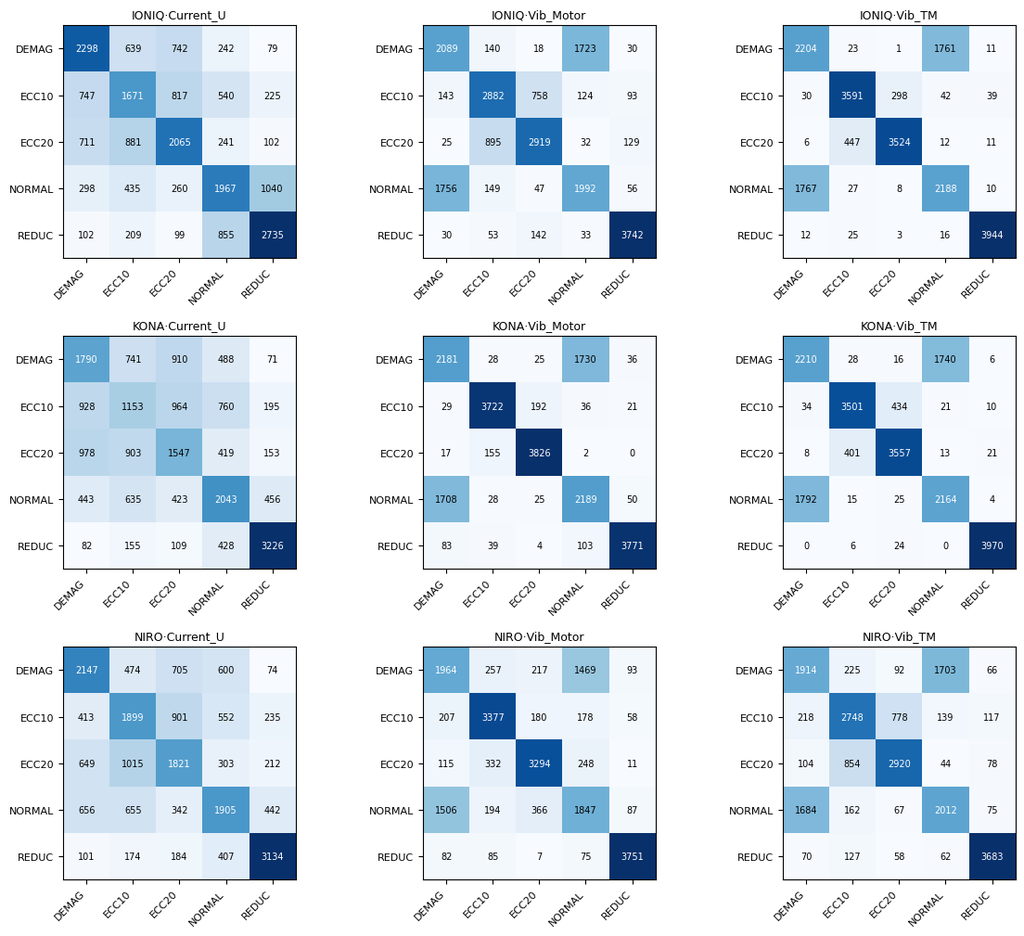

```
CPU times: total: 656 ms
Wall time: 666 ms
```

```python
%%time
# =====================================================================
#  평가 요약 — macro-F1 / per-class F1 / confusion matrix / fold 분산
# =====================================================================

import numpy as np, pandas as pd
import matplotlib.pyplot as plt

trained = [r for r in eval_rows if "macro_f1_mean" in r]

print("=== 학습된 슬롯 요약 ===")
if trained:
    summ = pd.DataFrame([{
        "slot":     f'{r["slot"][0]}·{r["slot"][1]}',
        "n_chunks": r["n_chunks"],
        "classes":  len(r["labels"]),
        "n_splits": r["n_splits"],
        "macro_F1": f'{r["macro_f1_mean"]:.3f} ± {r["macro_f1_std"]:.3f}',
        "accuracy": f'{r["acc_mean"]:.3f} ± {r["acc_std"]:.3f}',
    } for r in trained])
    print(summ.to_string(index=False))
else:
    print("CV 평가가 수행된 슬롯이 없습니다.")

for r in eval_rows:
    if "macro_f1_mean" not in r:
        print(f'[참고] {r["slot"]}: {r.get("status")}  (chunks={r.get("n_chunks")}, classes={r.get("classes")})')


def per_class_f1(cm, labels):
    cm = np.array(cm); out = {}
    for i, lab in enumerate(labels):
        tp = cm[i, i]; fp = cm[:, i].sum() - tp; fn = cm[i, :].sum() - tp
        p   = tp / (tp + fp) if (tp + fp) else 0.0
        rcl = tp / (tp + fn) if (tp + fn) else 0.0
        out[lab] = round(2 * p * rcl / (p + rcl), 3) if (p + rcl) else 0.0
    return out


for r in trained:
    cm, labels = np.array(r["confusion_matrix"]), r["labels"]
    print(f'\n■ {r["slot"][0]} · {r["slot"][1]}  (pooled CV confusion matrix)')
    print(pd.DataFrame(cm, index=[f"T:{l}" for l in labels],
                       columns=[f"P:{l}" for l in labels]).to_string())
    print("per-class F1:", per_class_f1(cm, labels))

# confusion matrix 히트맵 그리드
if trained:
    try:
        n = len(trained); cols = min(3, n); rows = (n + cols - 1) // cols
        fig, axes = plt.subplots(rows, cols, figsize=(4 * cols, 3.4 * rows), squeeze=False)
        for ax in axes.ravel():
            ax.axis("off")
        for k, r in enumerate(trained):
            ax = axes.ravel()[k]; ax.axis("on")
            cm, labels = np.array(r["confusion_matrix"]), r["labels"]
            ax.imshow(cm, cmap="Blues")
            ax.set_xticks(range(len(labels))); ax.set_xticklabels(labels, rotation=45, ha="right", fontsize=8)
            ax.set_yticks(range(len(labels))); ax.set_yticklabels(labels, fontsize=8)
            ax.set_title(f'{r["slot"][0]}·{r["slot"][1]}', fontsize=9)
            for i in range(len(labels)):
                for j in range(len(labels)):
                    ax.text(j, i, int(cm[i, j]), ha="center", va="center", fontsize=7,
                            color="white" if cm[i, j] > cm.max() / 2 else "black")
        plt.tight_layout(); plt.show()
    except Exception as e:
        print("히트맵 생략:", e)
```

## 7. (옵션) 예측 데모 — Anomaly Score

저장된 레지스트리를 불러와 검증 청크 몇 개를 예측하고, `AS = 1 − P(NORMAL)` 와 5클래스 확률을 확인합니다.

```python
%%time
# =====================================================================
#  (옵션) 예측 데모 — 5클래스 확률 + Anomaly Score
#   AS = 1 − P(NORMAL)
# =====================================================================

import joblib, numpy as np

reg = joblib.load(os.path.join(MODEL_DIR, "model_registry.joblib"))
if not reg:
    print("등록된 모델이 없습니다.")
else:
    key = next(iter(reg))
    X, y, g = load_slot_chunks(slots[key])
    k = min(8, len(X))
    proba = slot_proba(reg[key], X[:k])
    ni = CLASS_ORDER.index("NORMAL")
    print(f"슬롯 {key} — 청크 {k}개 예측\n")
    for i in range(k):
        AS = 1 - proba[i, ni]
        top = CLASS_ORDER[proba[i].argmax()]
        probs = " ".join(f"{c}:{proba[i, j]:.2f}" for j, c in enumerate(CLASS_ORDER))
        print(f"  실제={y[i]:7s} 예측={top:7s} AS={AS:.3f} | {probs}")

    # 참고: 대시보드 통합점수 = 0.6 × (센서 AS 평균) + 0.4 × (센서 AS 최고)
    print("\n※ 통합점수(대시보드)는 한 차종의 3개 센서 AS를 0.6×평균 + 0.4×최고 로 합산합니다.")
```

```
슬롯 ('IONIQ', 'Current_U') — 청크 8개 예측

  실제=NORMAL  예측=NORMAL  AS=0.408 | DEMAG:0.00 ECC10:0.00 ECC20:0.00 NORMAL:0.59 REDUC:0.41
  실제=NORMAL  예측=REDUC   AS=0.681 | DEMAG:0.00 ECC10:0.15 ECC20:0.00 NORMAL:0.32 REDUC:0.53
  실제=NORMAL  예측=NORMAL  AS=0.456 | DEMAG:0.00 ECC10:0.00 ECC20:0.00 NORMAL:0.54 REDUC:0.45
  실제=NORMAL  예측=REDUC   AS=0.779 | DEMAG:0.00 ECC10:0.00 ECC20:0.00 NORMAL:0.22 REDUC:0.78
  실제=NORMAL  예측=REDUC   AS=0.876 | DEMAG:0.00 ECC10:0.01 ECC20:0.00 NORMAL:0.12 REDUC:0.86
  실제=NORMAL  예측=REDUC   AS=0.772 | DEMAG:0.00 ECC10:0.00 ECC20:0.00 NORMAL:0.23 REDUC:0.77
  실제=NORMAL  예측=REDUC   AS=0.587 | DEMAG:0.00 ECC10:0.00 ECC20:0.00 NORMAL:0.41 REDUC:0.59
  실제=NORMAL  예측=REDUC   AS=0.944 | DEMAG:0.00 ECC10:0.00 ECC20:0.00 NORMAL:0.06 REDUC:0.94

※ 통합점수(대시보드)는 한 차종의 3개 센서 AS를 0.6×평균 + 0.4×최고 로 합산합니다.
CPU times: total: 2min 4s
Wall time: 3min 5s
```

# 6.19 개선 작업 모음 (C → B → A → D)

## (C)+(B) 예측 데모 — 한 차종 3센서 통합 + 균형 샘플링 + 정확한 latency

**기존 데모의 문제 3가지를 한 번에 고친다.**

1. **반쪽 데모** — 기존은 `next(iter(reg))` 로 슬롯 **1개만** 예측하고 통합점수는 print 안내문이었다. → 한 차종의 **3센서를 모두** 예측해 `AS = 1 − P(NORMAL)` 를 센서별로 구하고, `통합점수 = 0.6×평균 + 0.4×최고` 를 **실제로 계산**한다.
2. **최악의 케이스** — 청크를 앞에서 8개 자르면 한 클래스(예: NORMAL)만 잡혀 "정상을 고장이라 오탐" 하는 장면만 보였다. → `balanced_sample_idx` 로 **클래스가 골고루 섞이게** 뽑는다.
3. **무의미한 latency** — `%%time` 은 모델 로딩 + 예측 전부 섞여 3분으로 찍혔다. → 워밍업 후 **단일 청크 추론을 50회 반복** 측정해, 발표 기준 *"단일 청크 ≤ 100 ms"* 와 직접 비교한다.

> 전제: `reg` 의 key 가 `(vehicle, sensor)` 튜플 형태 (학습 표에 `IONIQ·Current_U` 로 찍힌 그대로). 만약 문자열(`"IONIQ_Current_U"`)이면 `k[0]` → `k.split("_")[0]` 로만 바꾸면 된다.

```python
import joblib, numpy as np, os, time

def balanced_sample_idx(y, k, seed=42):
    # 클래스가 골고루 섞이도록 k개 인덱스를 round-robin 으로 뽑는다.
    rng = np.random.default_rng(seed)
    y = np.asarray(y)
    classes = np.unique(y)

    by_class = {
        c: list(rng.permutation(np.where(y == c)[0]))
        for c in classes
    }

    ptr = {c: 0 for c in classes}
    picked = []

    while len(picked) < k:
        progressed = False

        for c in classes:
            if ptr[c] < len(by_class[c]):
                picked.append(int(by_class[c][ptr[c]]))
                ptr[c] += 1
                progressed = True

                if len(picked) >= k:
                    break

        if not progressed:
            break

    return picked


reg = joblib.load(os.path.join(MODEL_DIR, "model_registry.joblib"))

if not reg:
    print("등록된 모델이 없습니다.")

else:
    ni = CLASS_ORDER.index("NORMAL")

    # 1) 데모할 차종 하나 고르기
    vehicles = sorted({k[0] for k in reg})
    demo_vehicle = vehicles[0]

    demo_slots = [
        k for k in reg
        if k[0] == demo_vehicle
    ]

    print(
        f"=== 데모 차종: {demo_vehicle} / "
        f"센서 {len(demo_slots)}개 ===\n"
    )

    sensor_AS = {}

    # 2) 센서별 예측
    for key in demo_slots:
        X, y, g = load_slot_chunks(slots[key])

        k = min(8, len(X))
        idx = balanced_sample_idx(y, k)

        Xs = X[idx]
        ys = np.asarray(y)[idx]

        proba = slot_proba(reg[key], Xs)

        print(f"[{key[1]}] 청크 {k}개 예측 (클래스 균형)")

        as_list = []

        for i in range(k):
            AS = 1 - proba[i, ni]
            top = CLASS_ORDER[proba[i].argmax()]

            probs = " ".join(
                f"{c}:{proba[i, j]:.2f}"
                for j, c in enumerate(CLASS_ORDER)
            )

            hit = "O" if top == ys[i] else "X"

            print(
                f"  [{hit}] 실제={ys[i]:7s} "
                f"예측={top:7s} "
                f"AS={AS:.3f} | {probs}"
            )

            as_list.append(AS)

        sensor_AS[key[1]] = float(np.mean(as_list))

        print(
            f"  -> {key[1]} 평균 AS = "
            f"{sensor_AS[key[1]]:.3f}\n"
        )

    # 3) 대시보드 통합점수
    vals = list(sensor_AS.values())

    final = (
        0.6 * np.mean(vals)
        + 0.4 * np.max(vals)
    )

    print(
        f"※ {demo_vehicle} 통합 Anomaly Score "
        f"= 0.6×{np.mean(vals):.3f} "
        f"+ 0.4×{np.max(vals):.3f} "
        f"= {final:.3f}"
    )

    print(
        f"  (낮을수록 양호 / "
        f"환산점수 {round((1 - final) * 100)}점)"
    )

    # 4) 단일 청크 latency 측정
    key = demo_slots[0]

    X, _, _ = load_slot_chunks(slots[key])

    # 워밍업
    _ = slot_proba(reg[key], X[:1])

    n_iter = 50

    t0 = time.perf_counter()

    for _ in range(n_iter):
        slot_proba(reg[key], X[:1])

    per_chunk_ms = (
        (time.perf_counter() - t0)
        / n_iter
        * 1000
    )

    if per_chunk_ms <= 100:
        ok = "≤100ms 충족 → 다운샘플링 불필요"
    else:
        ok = "초과 → 다운샘플링 검토"

    print(
        f"\n[latency] 단일 청크 추론 "
        f"= {per_chunk_ms:.1f} ms ({ok})"
    )
```

```
=== 데모 차종: IONIQ / 센서 3개 ===

[Current_U] 청크 8개 예측 (클래스 균형)
  [O] 실제=DEMAG   예측=DEMAG   AS=0.863 | DEMAG:0.46 ECC10:0.31 ECC20:0.03 NORMAL:0.14 REDUC:0.07
  [X] 실제=ECC10   예측=NORMAL  AS=0.537 | DEMAG:0.00 ECC10:0.39 ECC20:0.00 NORMAL:0.46 REDUC:0.14
  [O] 실제=ECC20   예측=ECC20   AS=0.987 | DEMAG:0.14 ECC10:0.02 ECC20:0.82 NORMAL:0.01 REDUC:0.00
  [O] 실제=NORMAL  예측=NORMAL  AS=0.405 | DEMAG:0.00 ECC10:0.05 ECC20:0.04 NORMAL:0.60 REDUC:0.32
  [O] 실제=REDUC   예측=REDUC   AS=0.987 | DEMAG:0.00 ECC10:0.01 ECC20:0.01 NORMAL:0.01 REDUC:0.97
  [O] 실제=DEMAG   예측=DEMAG   AS=1.000 | DEMAG:0.78 ECC10:0.01 ECC20:0.20 NORMAL:0.00 REDUC:0.00
  [O] 실제=ECC10   예측=ECC10   AS=0.746 | DEMAG:0.28 ECC10:0.36 ECC20:0.06 NORMAL:0.25 REDUC:0.05
  [O] 실제=ECC20   예측=ECC20   AS=1.000 | DEMAG:0.02 ECC10:0.01 ECC20:0.98 NORMAL:0.00 REDUC:0.00
  -> Current_U 평균 AS = 0.816

[Vib_Motor] 청크 8개 예측 (클래스 균형)
  [O] 실제=DEMAG   예측=DEMAG   AS=0.779 | DEMAG:0.76 ECC10:0.02 ECC20:0.00 NORMAL:0.22 REDUC:0.00
  [X] 실제=ECC10   예측=ECC20   AS=1.000 | DEMAG:0.00 ECC10:0.42 ECC20:0.58 NORMAL:0.00 REDUC:0.00
  [O] 실제=ECC20   예측=ECC20   AS=1.000 | DEMAG:0.00 ECC10:0.00 ECC20:1.00 NORMAL:0.00 REDUC:0.00
  [O] 실제=NORMAL  예측=NORMAL  AS=0.283 | DEMAG:0.28 ECC10:0.00 ECC20:0.00 NORMAL:0.72 REDUC:0.00
  [X] 실제=REDUC   예측=ECC10   AS=0.619 | DEMAG:0.05 ECC10:0.43 ECC20:0.14 NORMAL:0.38 REDUC:0.00
  [O] 실제=DEMAG   예측=DEMAG   AS=0.648 | DEMAG:0.65 ECC10:0.00 ECC20:0.00 NORMAL:0.35 REDUC:0.00
  [O] 실제=ECC10   예측=ECC10   AS=0.931 | DEMAG:0.08 ECC10:0.69 ECC20:0.16 NORMAL:0.07 REDUC:0.00
  [O] 실제=ECC20   예측=ECC20   AS=1.000 | DEMAG:0.00 ECC10:0.00 ECC20:1.00 NORMAL:0.00 REDUC:0.00
  -> Vib_Motor 평균 AS = 0.783

[Vib_TM] 청크 8개 예측 (클래스 균형)
  [O] 실제=DEMAG   예측=DEMAG   AS=0.817 | DEMAG:0.82 ECC10:0.00 ECC20:0.00 NORMAL:0.18 REDUC:0.00
  [O] 실제=ECC10   예측=ECC10   AS=1.000 | DEMAG:0.00 ECC10:0.99 ECC20:0.00 NORMAL:0.00 REDUC:0.00
  [O] 실제=ECC20   예측=ECC20   AS=1.000 | DEMAG:0.00 ECC10:0.00 ECC20:1.00 NORMAL:0.00 REDUC:0.00
  [O] 실제=NORMAL  예측=NORMAL  AS=0.010 | DEMAG:0.01 ECC10:0.00 ECC20:0.00 NORMAL:0.99 REDUC:0.00
  [O] 실제=REDUC   예측=REDUC   AS=1.000 | DEMAG:0.00 ECC10:0.00 ECC20:0.00 NORMAL:0.00 REDUC:1.00
  [O] 실제=DEMAG   예측=DEMAG   AS=0.659 | DEMAG:0.66 ECC10:0.00 ECC20:0.00 NORMAL:0.34 REDUC:0.00
  [O] 실제=ECC10   예측=ECC10   AS=0.999 | DEMAG:0.00 ECC10:0.99 ECC20:0.01 NORMAL:0.00 REDUC:0.00
  [O] 실제=ECC20   예측=ECC20   AS=1.000 | DEMAG:0.00 ECC10:0.00 ECC20:1.00 NORMAL:0.00 REDUC:0.00
  -> Vib_TM 평균 AS = 0.811

※ IONIQ 통합 Anomaly Score = 0.6×0.803 + 0.4×0.816 = 0.808
  (낮을수록 양호 / 환산점수 19점)

[latency] 단일 청크 추론 = 16.5 ms (≤100ms 충족 → 다운샘플링 불필요)
```